# GWAS Final Report

Jake Sauter

4/29/2021

## **Background**

The data associated with the following analyses represents the mRNA expression levels of five different transcripts of interest (ERAP2, PEX6, FAHD1, GFM1 and MARCHF7), measured from four European or European-related populations. mRNA expression profiles were quantified through Next-Generation Sequencing (NGS) of reverse-transcribed cDNA of RNA samples dervied from Lymphoblastic Cell Lines (LCLs) generated from each individual in the study, originating from the 1000 Genomes Project.

The phenotype data for this study was generated by the Genetic European Variation in Health and Disease (gEUVADIS). A published Nature Article ([Transcriptome and genome sequencing uncovers functional variation in humans](https://www.nature.com/articles/nature12531)) resulted from these data, and the data can be accessed via an [International Genome Sample Resource Data Portal](https://www.internationalgenome.org/data-portal/data-collection/geuvadis). The individuals included in the following analyses are apart of four seperate populations, **CEU** (Utah (U.S.A) residents with European ancestry), **FIN** (Finns), **GBR** (British) and **TSI** (Toscani).

The goal of the following analysis is to reproducilby locate positions of causal single nucleotide polymorphisms (SNPs) for the five LCL-mRNA related phenotypes aquired in the reference study. In order to accomplish this goal, a standard Genome Wide Association Study (GWAS) will be performed, in which independent hypothesis tests for association will be performed for each genotype-phenotype pair. Our aim is to identify genomic locations in which we calculate a significant association between a difference in genotype and observed phenotype, indicated by a significant ($\alpha < 0.05$) multiple testing corrected p-value for these locations. Due to the nature of the complex biological processes occuring with the information stored in genomic DNA, a significant p-value (for other than statitical reasons) may not indicate a true causual polymorphism is present at the exact location, more specifically due to linkage disequilibrium, or less formally, observed correlation between closely co-located genomic positions.

## **Model Setup**

In order to analyze the given genetic data, we will make use of the qunantiative genetic model for a muliple regression. Both an additive ($X_a(A_1A_1) = -1, X_a(A_1A_2) = 0, X_a(A_2A_2) = 1$ and dominant ($X_d(A_1A_1) = -1, X_d(A_1A_2) = 1, X_d(A_2A_2) = -1$ genetic coding will be utitlized in our multiple regession model equation ($Y = \beta_{\mu} + X_a \beta_a + X_d \beta_d + \epsilon$) where $\epsilon ~ N(0, \sigma^2)$. This set of model and encodings allow us to capture the relationship between the genotype information ($X_a$, $X_d$) and the continous phenotype ($Y$), while preserving our genetic understanding of additive and dominant allele effects.

In the following analyses, we will use this model to perform a hypothesis test with a null hypothesis $H_0: \beta_a = 0 \cap \beta_d = 0$ (indicating that additive or dominant genetic effects were not found to be assocaited with the phenotypic difference) vs our alternative hypothesis $H_a: \beta_a \neq 0 \cup \beta_d \neq 0$ (indicating that either one or both of addiditive genetic effects are associated with the observed phenotypic difference).

## **Understanding the Data**

### **Genentic Phenotype Information**

Included in the data made availbe to us for this study is more information about the previosly described phenotypes. We see the five phenotypes present in the `symbol` column, along with information about where the gene encoding for the measured transcripts is located.

| probe | chromosome | start | end | symbol |
| --- | --- | --- | --- | --- |
| ENSG00000136536.9 | 2 | 159712456 | 159768582 | MARCH7 |
| ENSG00000180185.7 | 16 | 1827223 | 1840206 | FAHD1 |
| ENSG00000124587.9 | 6 | 42963872 | 42979242 | PEX6 |
| ENSG00000164308.12 | 5 | 96875939 | 96919702 | ERAP2 |
| ENSG00000168827.9 | 3 | 158644496 | 158692571 | GFM1 |

### **Phenotypes**

The phenotype data for this study has been provided in a relatively common and expected format, with one row per individual meansured, and one column for each of the measured phenotypes. A sample selection of the phenotype data for six individuals is shown below.

|  | ERAP2 | PEX6 | FAHD1 | GFM1 | MARCH7 |
| --- | --- | --- | --- | --- | --- |
| HG00096 | -1.166337 | -0.6859358 | -0.3062421 | 0.9275844 | 0.3600088 |
| HG00097 | -1.045803 | -0.1789576 | -1.0333305 | -0.6676644 | -1.7782530 |
| HG00099 | 1.045803 | -0.8945747 | -2.5242603 | -2.7590424 | -2.5242603 |
| HG00100 | 0.223446 | -0.0982433 | 1.1521112 | 0.2533471 | 0.0545189 |
| HG00101 | -0.223446 | 0.8625121 | 1.3782830 | 1.0842344 | 0.2608569 |
| HG00102 | -1.457685 | -0.3291676 | -0.1863454 | -1.1663369 | -2.3783289 |

### **Genotypes**

Below we see that we have **50,000** genotype markers for each of our **344** individuals. Each individual is represented in a **row** in our `genotype` data frame, with each **column** corresponding the the number of minor alleles the individual has present in their DNA.

|  | rs10399749 | rs62641299 | rs115523412 | rs75932129 | rs10900604 |
| --- | --- | --- | --- | --- | --- |
| HG00096 | 0 | 2 | 0 | 1 | 1 |
| HG00097 | 0 | 2 | 0 | 2 | 0 |
| HG00099 | 1 | 1 | 0 | 0 | 1 |
| HG00100 | 0 | 2 | 0 | 2 | 0 |
| HG00101 | 1 | 2 | 0 | 1 | 1 |
| HG00102 | 0 | 2 | 0 | 1 | 0 |
| HG00103 | 0 | 2 | 0 | 2 | 0 |
| HG00104 | 0 | 2 | 0 | 1 | 0 |
| HG00106 | 1 | 2 | 0 | 1 | 0 |
| HG00108 | 1 | 2 | 0 | 2 | 0 |

### **SNP Info**

Provided in the study data we also have information regarding the location of each genotype analyzed in the study, which will allow us later to ensure we are depicting the genotypes in the correction location along the genome.

| chromosome | position | id |
| --- | --- | --- |
| 1 | 55298 | rs10399749 |
| 1 | 79049 | rs62641299 |
| 1 | 826577 | rs115523412 |
| 1 | 861386 | rs75932129 |
| 1 | 863019 | rs10900604 |
| 1 | 875399 | rs58686784 |

### **Covariate Information**

Covariates of **Population** and **Sex** were measured in this study. In this report we will model the genotype-phenotype relationship both with and without including the covariate information shown below.

|  | Population | Sex |
| --- | --- | --- |
| HG00096 | GBR | MALE |
| HG00097 | GBR | FEMALE |
| HG00099 | GBR | FEMALE |
| HG00100 | GBR | FEMALE |
| HG00101 | GBR | MALE |
| HG00102 | GBR | FEMALE |

An important aspect of including covariates while modelling is ensuring a stable and informative model. Practially, this required a sufficient sample size per covariate-defined population. Below we see that each covariate controlled population has over **30** samples, indicating that we should have enough data/information here in order to control for both covariates with introducing non-robust model characteristics.

| Population | Sex | n |
| --- | --- | --- |
| CEU | FEMALE | 37 |
| CEU | MALE | 41 |
| FIN | FEMALE | 55 |
| FIN | MALE | 34 |
| GBR | FEMALE | 46 |
| GBR | MALE | 39 |
| TSI | FEMALE | 43 |
| TSI | MALE | 49 |

## **Checking the Phenotype Data**

From the information above, it is clear that we are dealing with **5** phenotypes from **344** individuals, each phenotype describing the **continuous** variable of mRNA expression of the genes of interest.

### **Phenotype Histograms**

All phenotypes appear to be be normally distributed between -3 and 3. This fits our expection of Normality in GWAS

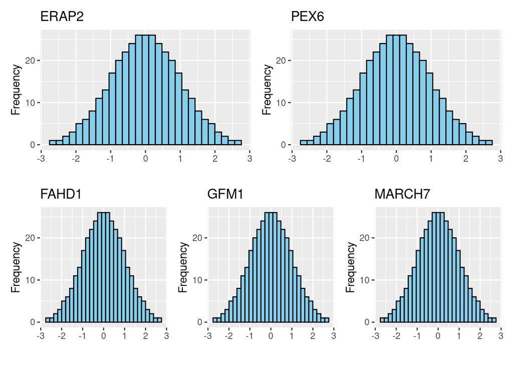

### **Checking for Odd Phenotype Values**

There does not seem to be any `NA` or outlier phenotypic values present in the data.

```
[1] FALSE
```

```
     ERAP2              PEX6             FAHD1              GFM1
 Min.   :-2.7590   Min.   :-2.7590   Min.   :-2.7590   Min.   :-2.7590
 1st Qu.:-0.6699   1st Qu.:-0.6699   1st Qu.:-0.6699   1st Qu.:-0.6699
 Median : 0.0000   Median : 0.0000   Median : 0.0000   Median : 0.0000
 Mean   : 0.0000   Mean   : 0.0000   Mean   : 0.0000   Mean   : 0.0000
 3rd Qu.: 0.6699   3rd Qu.: 0.6699   3rd Qu.: 0.6699   3rd Qu.: 0.6699
 Max.   : 2.7590   Max.   : 2.7590   Max.   : 2.7590   Max.   : 2.7590
     MARCH7
 Min.   :-2.7590
 1st Qu.:-0.6699
 Median : 0.0000
 Mean   : 0.0000
 3rd Qu.: 0.6699
 Max.   : 2.7590
```

## **Check and Filter Genotype Data**

### **Data Quality Checks**

Filter genotypes:

- Remove **individuals** with more than 10% missing data across all genotypes
- Remove **genotypes** with more than 5% missing data across all individuals.
- Remove **genotypes** with an MAF less than 5%

From the information below, we can see that no genotypes with an MAF of less than 5% are present in our data.

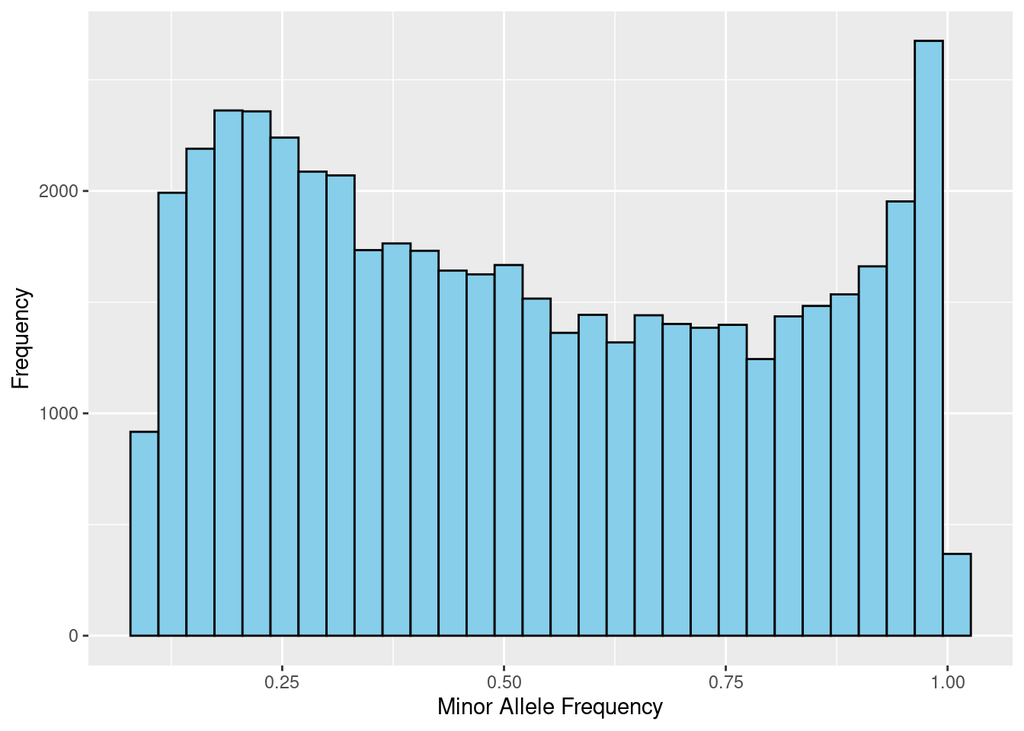

```
[1] 0
```

### **Principle Components Analysis**

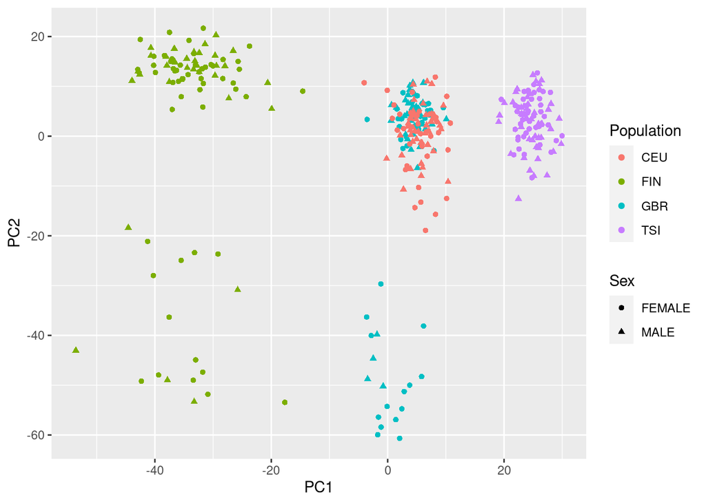

## **Performing GWAS Without Covariates**

### **QQ Plots**

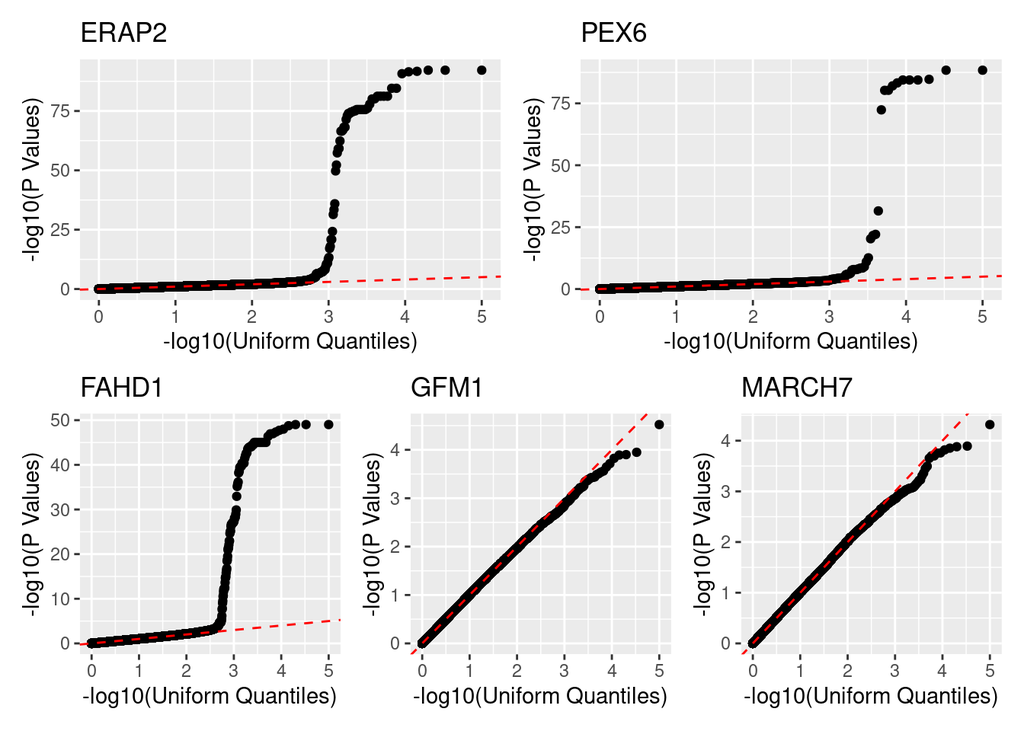

### **Manhattan Plots**

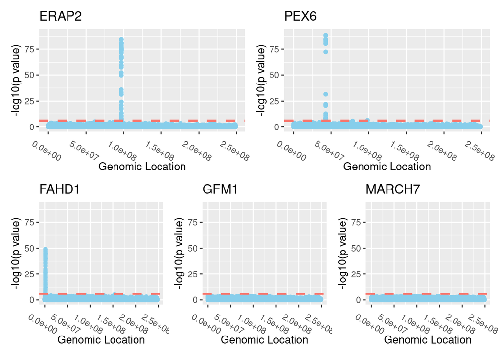

Of the three phenotypes that we have observed significant hits for, we will take a closer look at the local regions where the hits were found to be.

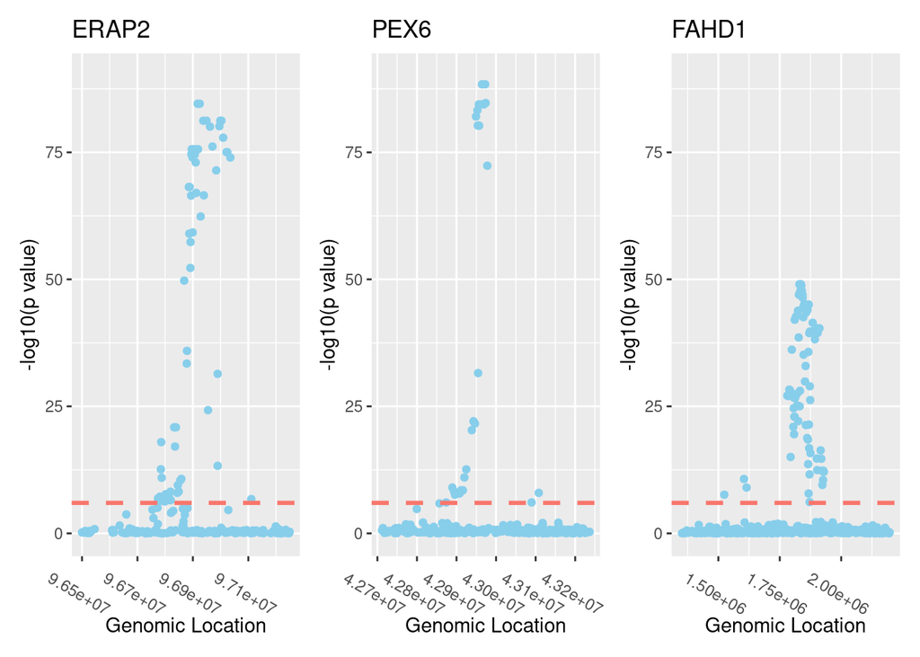

## **Performing GWAS With Covariates**

### **QQ Plots**

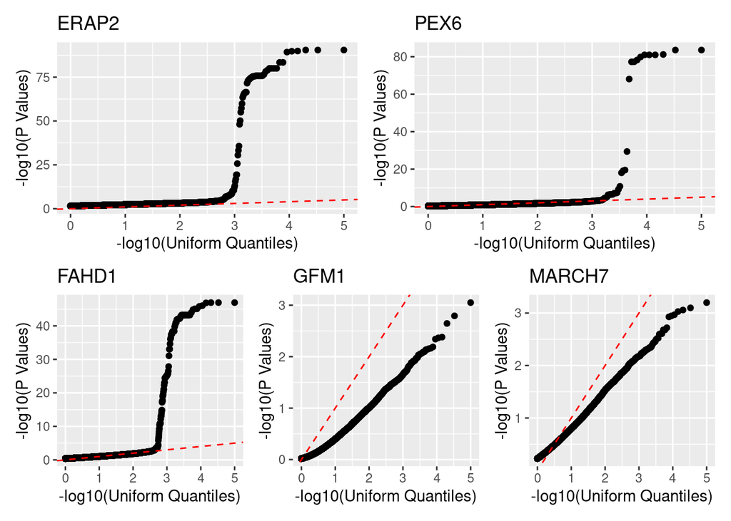

### **Manhattain Plots**

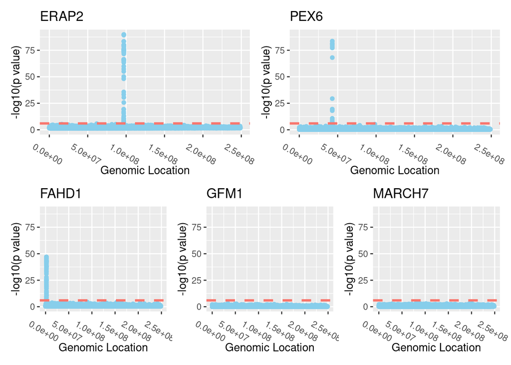

Of the three phenotypes that we have observed significant hits for, we will take a closer look at the local regions where the hits were found to be. We see below that we have found the same hits with and without covariates included in our model.

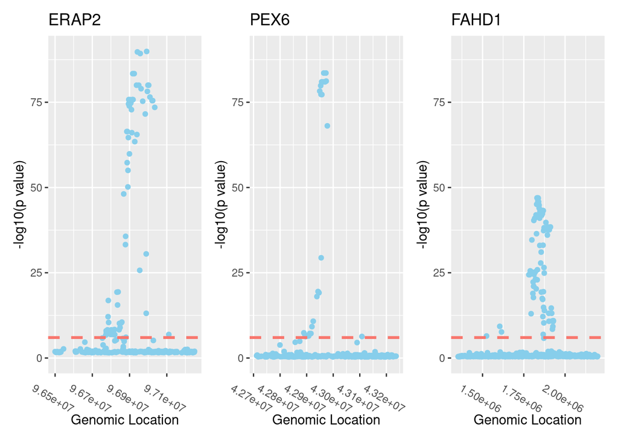

## **Table of Most Significant Hits**

[output not shown]